# Stroop Task

In this project, a classic phenomenon from experimental psychology called the Stroop Effect is the main investigation topic. I will learn a little bit about the experiment, create a hypothesis regarding the outcome of the task, then go through the task. Some data collected from others who have performed the same task have been provided and I will compute some statistics describing the results. Finally, I interpret the results in terms of hypotheses.

### Question 1: Independent and Independent variables

In the Stroop task project one can identify the independent and dependent as follow:

Independent variable: Word formats, congruent and incongruent. Dependent variable: Performance, time to name the ink colors.

On the other words, the word formats are on the x axis, while the performances are on the y axis.

### Question 2: Hypotheses and Test

Since we want to see if the performance is significantly affected by the difference in word formats, we can formulate the hypotheses as follow:

HO: myucong - myuincong = 0

HA: myucong - myuincong != 0

The Ho states that the population does not have significantly different performance means between congruent and incongruent. On the opposite, the alternative hypothesis states that there is significant difference between congruent and incongruent population mean.

To determine the appropriate hypothesis testing to be used, some important specifics of the Stroop test are listed as follow.

1. There is no population standard deviation and mean data available
2. The subjects take test twice because the same sample receives two treatments.

Considering the facts above, dependent t-test will be used to determine if the two sets of data (congruent and incongruent) are significantly different from each other.

### Question 3: Descriptive Statistics

Table 1 shows the raw data of the Stroop test result. There are twenty-four subjects, and the values indicate the time taken in second to complete the test. By using Excel, we can generate the descriptive statistics of the data sets. Table 2 illustrates the statistics of each sample.

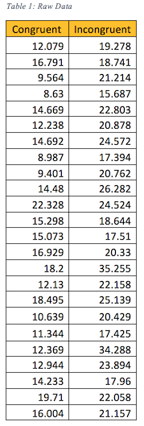

```python
from IPython.display import Image
Image("table1.png")
```

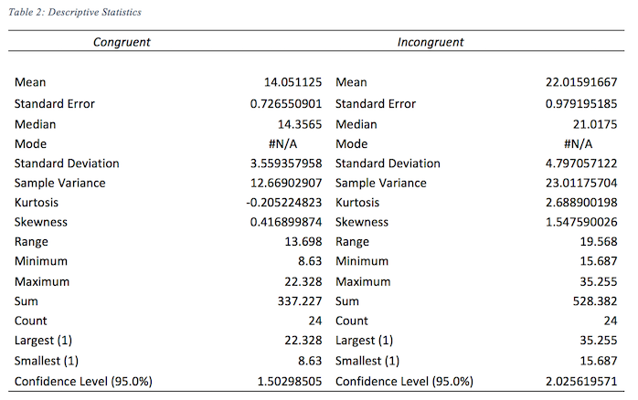

```python
Image("table2.png")
```

### Question 4: Data Visualization

As we can see from Figure 1 and Figure 2, the samples histogram charts are more less following the normal curve. The incongruent histogram has more positive skewness, however as also shown in descriptive statistics section, the mean and median of each sample are close.

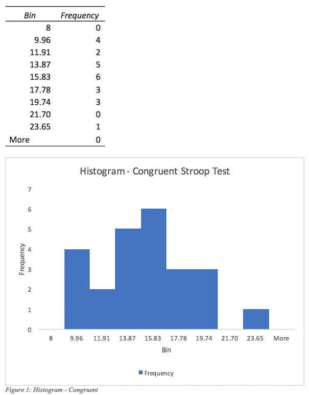

```python
Image("figure1.png")
```

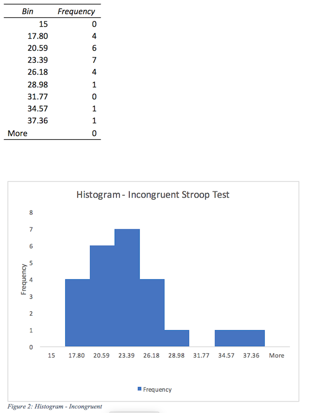

```python
Image("figure2.png")
```

### Question 5: Statistical Test

As mentioned in Question 2 section above, we use the t-test determine if we can reject Ho or not. The confidence level is 95%, thus the is 0.05. One tail test is used since we know that it always takes more time for subjects to do the incongruent test compared to the congruent one. Again, we leverage Excel’s Data Analysis tool to perform dependent t-test, specifically, the t-test paired two sample for means.

Running the test for the dataset, we get the result as follow.

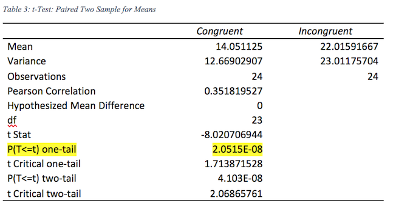

```python
Image("table3.png")
```

Because the P(t) value is 2.0515E-08 which is much smaller than value 0.05, there is enough evident reject Ho and we can conclude that there is significant performance difference between congruent and incongruent.

### Question 6: Optional

One of the theories that try to explain this observed effect is processing speed. According to this theory, brain reads the words significantly faster than it recognizes colors. Whenever there is conflict regarding the words and colors (incongruent), and the task is to report the color, the word information arrives at the decision making stage before the color information, thus creating processing confusion. If the task is to report the word, the decision making can quickly proceed without confusion.

The research can be replicated and extended. For example, rather than using the color words, we can use non-sense words and examine if the difference is still significant. Will the brain focus better on the color if the words do not have meanings?

### Works Cited

Dependent-tests. (n.d.). Retrieved 06 25, 2017, from California State University, Fresno: https://www.fresnostate.edu/academics/graduatenet/documents/students/stats/CalcDependent_t-test.pdf Stroop effect. (n.d.). Retrieved May 27, 2017, from Wikipedia: https://en.wikipedia.org/wiki/Stroop_effect Student's t-test. (n.d.). Retrieved May 27, 2017, from Wikipedia: https://en.wikipedia.org/wiki/Student%27s_t-test